# UFJF | FACULDADE DE ECONOMIA | ECONS

# 5.3 Estatística multivariada

Esta subseção tem apenas o perfil introdutório [Fellipe Gomes](https://gomesfellipe.github.io/post/2018-01-01-analise-multivariada-em-r/an%C3%A1lise-multivariada-em-r/) e [Ralph Silva](http://www.im.ufrj.br/ralph/multivariada.html) tem trabalhos mais aprofundatos para quem quer ingressar mais intensamente em multivariada.

É fundamental conhecer o pacote [MVar.pt](https://cran.r-project.org/web/packages/MVar.pt/MVar.pt.pdf) que lista todos os principais modelos em multivariada.

Base para maioria dos modelos de BIGDATA e aprendizado de máquina por meio de algortimos, seu uso permita extrair informações de grandes dados computacionais.

Os modelos básicos são a Análise Fatorial e Análise de Componentes Principais, por serem básicos não é necessário pacotes adcionais para estes dois modelos, entre as vantagens:

- Permite analisar fatores que não são diretamente observáveis (variáveis latentes), com base em um conjunto de variáveis observáveis.
- Reduzir a dimensão dos dados quando existem um número elevados variáveis (correlacionadas) observadas a um conjunto reduzindo de fatores (não correlacionados).
- Além das possibildiades analíticas, seus resultados podem ser empregados em outros modelos como regressões, atravéz dos escores das variáveis, cargas fatoriais ou dos fatores para aumentar eficiência do modelo.

  **Bibliotecas**:

```r
#library(ggfortify) # Data Visualization Tools for Statistical Analysis Results
# library(MVar.pt) # similar a MVar, com saídas em português
# https://cran.r-project.org/web/packages/MVar.pt/MVar.pt.pdf
# library(MASS) # Support Functions and Datasets for Venables and Ripley's MASS
library("haven") # ignore labels pull numbers
```

```r
pnad <-  read_dta('Exemplo/pnad_mod.dta')
  summary(pnad)
```

```
       uf             sexo           idade           raca           migra
 Min.   :11.00   Min.   :2.000   Min.   : 0.0   Min.   :2.000   Min.   :1.000
 1st Qu.:24.00   1st Qu.:2.000   1st Qu.:15.0   1st Qu.:2.000   1st Qu.:1.000
 Median :31.00   Median :4.000   Median :29.0   Median :4.000   Median :1.000
 Mean   :31.56   Mean   :3.023   Mean   :31.2   Mean   :4.979   Mean   :1.818
 3rd Qu.:41.00   3rd Qu.:4.000   3rd Qu.:45.0   3rd Qu.:8.000   3rd Qu.:3.000
 Max.   :53.00   Max.   :4.000   Max.   :95.0   Max.   :8.000   Max.   :3.000

   analfabeto       infantil          educ             ativ
 Min.   :1.000   Min.   :1.000   Min.   : 0.000   Min.   :1.000
 1st Qu.:1.000   1st Qu.:3.000   1st Qu.: 1.000   1st Qu.:1.000
 Median :1.000   Median :3.000   Median : 5.000   Median :1.000
 Mean   :1.359   Mean   :2.988   Mean   : 5.923   Mean   :1.397
 3rd Qu.:1.000   3rd Qu.:3.000   3rd Qu.:11.000   3rd Qu.:2.000
 Max.   :3.000   Max.   :3.000   Max.   :15.000   Max.   :2.000
                 NA's   :3563    NA's   :9        NA's   :595
      ocup           renda            ren_fam           componentes
 Min.   :1.000   Min.   :    0.0   Min.   :0.000e+00   Min.   : 1.000
 1st Qu.:1.000   1st Qu.:  320.0   1st Qu.:6.220e+02   1st Qu.: 3.000
 Median :1.000   Median :  500.0   Median :1.182e+03   Median : 4.000
 Mean   :1.072   Mean   :  940.3   Mean   :2.530e+10   Mean   : 3.795
 3rd Qu.:1.000   3rd Qu.:  930.0   3rd Qu.:2.200e+03   3rd Qu.: 5.000
 Max.   :2.000   Max.   :30000.0   Max.   :1.000e+12   Max.   :16.000
 NA's   :1899    NA's   :2073      NA's   :11          NA's   :11
      peso            V4617            V4618             ida2
 Min.   :  18.0   Min.   :110001   Min.   :   1.0   Min.   :   0
 1st Qu.: 249.0   1st Qu.:240014   1st Qu.:  70.0   1st Qu.: 225
 Median : 488.0   Median :310049   Median : 161.5   Median : 841
 Mean   : 483.8   Mean   :315668   Mean   : 258.1   Mean   :1387
 3rd Qu.: 621.0   3rd Qu.:410007   3rd Qu.: 414.0   3rd Qu.:2025
 Max.   :1159.0   Max.   :530002   Max.   :1009.0   Max.   :9025

    lnrenda         per_capita            branco           negro
 Min.   : 2.303   Min.   :0.000e+00   Min.   :0.0000   Min.   :0.00000
 1st Qu.: 6.028   1st Qu.:1.710e+02   1st Qu.:0.0000   1st Qu.:0.00000
 Median : 6.397   Median :3.370e+02   Median :0.0000   Median :0.00000
 Mean   : 6.419   Mean   :7.836e+09   Mean   :0.4498   Mean   :0.08059
 3rd Qu.: 6.908   3rd Qu.:6.500e+02   3rd Qu.:1.0000   3rd Qu.:0.00000
 Max.   :10.309   Max.   :1.000e+12   Max.   :1.0000   Max.   :1.00000
 NA's   :2244     NA's   :11
     pardo             masc           migrante
 Min.   :0.0000   Min.   :0.0000   Min.   :0.0000
 1st Qu.:0.0000   1st Qu.:0.0000   1st Qu.:0.0000
 Median :0.0000   Median :0.0000   Median :0.0000
 Mean   :0.4696   Mean   :0.4884   Mean   :0.4089
 3rd Qu.:1.0000   3rd Qu.:1.0000   3rd Qu.:1.0000
 Max.   :1.0000   Max.   :1.0000   Max.   :1.0000
```

```r
# correções
pnad$V4617   <- NULL
pnad$V4618   <- NULL
pnad$migra   <- NULL
pnad$uf      <- NULL
pnad$infantil<- NULL
pnad$ocup    <- NULL
pnad$renda   <- NULL
pnad$lnrenda <- NULL
pnad$masc    <- NULL
pnad$branco  <- NULL
pnad$raca    <- NULL
pnad$ren_fam <- ifelse(pnad$ren_fam>=999999,0,pnad$ren_fam)
pnad$per_capita <- ifelse(pnad$per_capita>=999999,0,pnad$per_capita)
```

```r
pnad<- na.omit(pnad)
summary(pnad)
```

```
      sexo           idade         analfabeto         educ
 Min.   :2.000   Min.   :10.00   Min.   :1.000   Min.   : 0.000
 1st Qu.:2.000   1st Qu.:21.00   1st Qu.:1.000   1st Qu.: 4.000
 Median :4.000   Median :33.00   Median :1.000   Median : 7.000
 Mean   :3.022   Mean   :35.97   Mean   :1.183   Mean   : 6.953
 3rd Qu.:4.000   3rd Qu.:48.00   3rd Qu.:1.000   3rd Qu.:11.000
 Max.   :4.000   Max.   :95.00   Max.   :3.000   Max.   :15.000
      ativ          ren_fam       componentes          peso
 Min.   :1.000   Min.   :    0   Min.   : 1.000   Min.   :  18.0
 1st Qu.:1.000   1st Qu.:  622   1st Qu.: 3.000   1st Qu.: 249.0
 Median :1.000   Median : 1180   Median : 4.000   Median : 488.0
 Mean   :1.397   Mean   : 1934   Mean   : 3.675   Mean   : 485.6
 3rd Qu.:2.000   3rd Qu.: 2100   3rd Qu.: 4.000   3rd Qu.: 621.0
 Max.   :2.000   Max.   :39000   Max.   :16.000   Max.   :1159.0
      ida2        per_capita          negro             pardo
 Min.   : 100   Min.   :    0.0   Min.   :0.00000   Min.   :0.0000
 1st Qu.: 441   1st Qu.:  178.1   1st Qu.:0.00000   1st Qu.:0.0000
 Median :1089   Median :  350.0   Median :0.00000   Median :0.0000
 Mean   :1630   Mean   :  624.7   Mean   :0.08652   Mean   :0.4616
 3rd Qu.:2304   3rd Qu.:  634.4   3rd Qu.:0.00000   3rd Qu.:1.0000
 Max.   :9025   Max.   :33000.0   Max.   :1.00000   Max.   :1.0000
    migrante
 Min.   :0.0000
 1st Qu.:0.0000
 Median :0.0000
 Mean   :0.4558
 3rd Qu.:1.0000
 Max.   :1.0000
```

```r
corPNAD <- round(cor(pnad),4)    # 4 casas decimais
corPNAD
```

A matrix: 13 × 13 of type dbl

|  | sexo | idade | analfabeto | educ | ativ | ren_fam | componentes | peso | ida2 | per_capita | negro | pardo | migrante |
| --- | --- | --- | --- | --- | --- | --- | --- | --- | --- | --- | --- | --- | --- |
| sexo | 1.0000 | 0.0460 | 0.0048 | 0.0355 | 0.2448 | -0.0516 | -0.0515 | 0.0328 | 0.0550 | -0.0392 | -0.0165 | -0.0287 | 0.0151 |
| idade | 0.0460 | 1.0000 | 0.2771 | -0.1459 | -0.0152 | 0.0924 | -0.2691 | 0.0385 | 0.9700 | 0.1393 | 0.0384 | -0.0824 | 0.3128 |
| analfabeto | 0.0048 | 0.2771 | 1.0000 | -0.4890 | 0.0806 | -0.1100 | -0.0266 | 0.0098 | 0.2886 | -0.0860 | 0.0609 | 0.0893 | 0.0718 |
| educ | 0.0355 | -0.1459 | -0.4890 | 1.0000 | -0.2554 | 0.3756 | -0.0985 | -0.0220 | -0.2041 | 0.3356 | -0.0780 | -0.1609 | -0.0109 |
| ativ | 0.2448 | -0.0152 | 0.0806 | -0.2554 | 1.0000 | -0.0735 | 0.0492 | 0.0049 | 0.1037 | -0.0772 | 0.0078 | 0.0099 | -0.0722 |
| ren_fam | -0.0516 | 0.0924 | -0.1100 | 0.3756 | -0.0735 | 1.0000 | 0.0000 | -0.0259 | 0.0795 | 0.8431 | -0.0668 | -0.1488 | 0.0742 |
| componentes | -0.0515 | -0.2691 | -0.0266 | -0.0985 | 0.0492 | 0.0000 | 1.0000 | -0.0455 | -0.2561 | -0.1957 | 0.0161 | 0.1113 | -0.1307 |
| peso | 0.0328 | 0.0385 | 0.0098 | -0.0220 | 0.0049 | -0.0259 | -0.0455 | 1.0000 | 0.0368 | -0.0051 | -0.0099 | -0.1198 | -0.0054 |
| ida2 | 0.0550 | 0.9700 | 0.2886 | -0.2041 | 0.1037 | 0.0795 | -0.2561 | 0.0368 | 1.0000 | 0.1285 | 0.0308 | -0.0809 | 0.2791 |
| per_capita | -0.0392 | 0.1393 | -0.0860 | 0.3356 | -0.0772 | 0.8431 | -0.1957 | -0.0051 | 0.1285 | 1.0000 | -0.0574 | -0.1421 | 0.0879 |
| negro | -0.0165 | 0.0384 | 0.0609 | -0.0780 | 0.0078 | -0.0668 | 0.0161 | -0.0099 | 0.0308 | -0.0574 | 1.0000 | -0.2850 | -0.0022 |
| pardo | -0.0287 | -0.0824 | 0.0893 | -0.1609 | 0.0099 | -0.1488 | 0.1113 | -0.1198 | -0.0809 | -0.1421 | -0.2850 | 1.0000 | -0.0484 |
| migrante | 0.0151 | 0.3128 | 0.0718 | -0.0109 | -0.0722 | 0.0742 | -0.1307 | -0.0054 | 0.2791 | 0.0879 | -0.0022 | -0.0484 | 1.0000 |

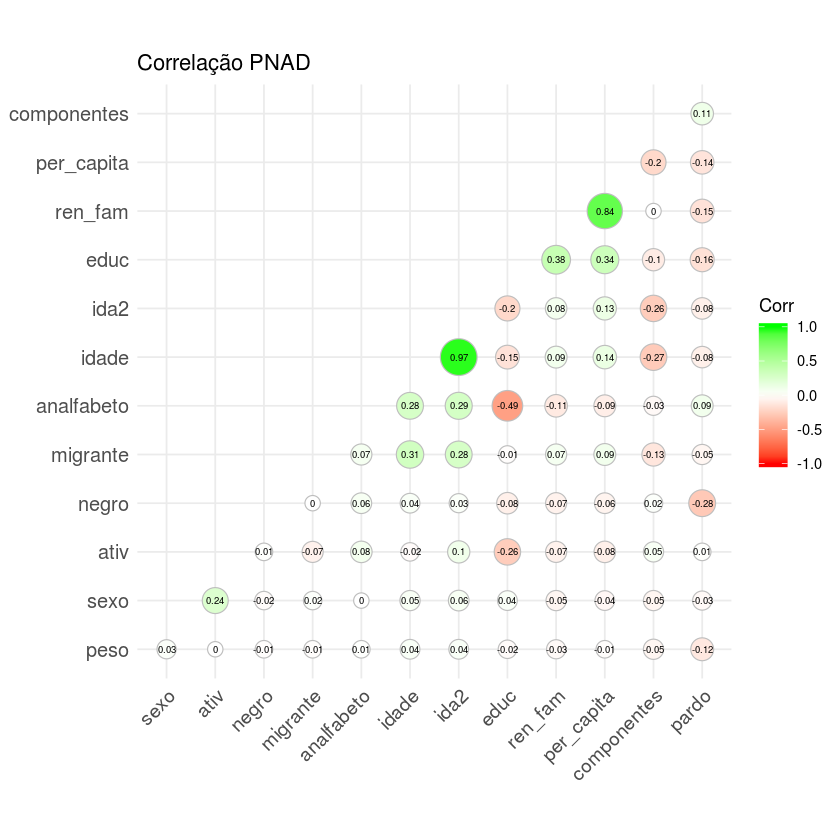

```r
library(ggplot2)
library(ggcorrplot)
ggcorrplot(corPNAD, hc.order = TRUE, type = "lower", lab = TRUE, lab_size = 2, method="circle",  colors = c("red", "white", "green"),  title="Correlação PNAD")
```

**Análise fatorial**

```
factanal(x, factors, data = NULL, covmat = NULL, n.obs = NA,
         subset, na.action, start = NULL,
         scores = c("none", "regression", "Bartlett"),
         rotation = "varimax", control = NULL, ...)
```

```r
##### Analise fatorial (maxima verossimilhanca)
AF <-factanal(pnad, factors = 5) # 3 exige um numero de vetores independentes >=3
AF
table(pnad$sexo)
```

```
Call:
factanal(x = pnad, factors = 5)

Uniquenesses:
       sexo       idade  analfabeto        educ        ativ     ren_fam
      0.917       0.005       0.712       0.005       0.005       0.005
componentes        peso        ida2  per_capita       negro       pardo
      0.895       0.982       0.039       0.281       0.897       0.005
   migrante
      0.896

Loadings:
            Factor1 Factor2 Factor3 Factor4 Factor5
sexo                                         0.273
idade        0.973           0.197
analfabeto   0.187           0.500
educ                 0.238  -0.965
ativ        -0.109           0.223           0.966
ren_fam              0.983  -0.139
componentes -0.296           0.103
peso                                -0.128
ida2         0.931           0.252           0.152
per_capita   0.116   0.827  -0.135
negro                               -0.313
pardo               -0.175   0.182   0.963
migrante     0.309

               Factor1 Factor2 Factor3 Factor4 Factor5
SS loadings      2.067   1.759   1.423   1.062   1.045
Proportion Var   0.159   0.135   0.109   0.082   0.080
Cumulative Var   0.159   0.294   0.404   0.485   0.566

Test of the hypothesis that 5 factors are sufficient.
The chi square statistic is 524.32 on 23 degrees of freedom.
The p-value is 3.03e-96
```

```
   2    4
1600 1671
```

```r
# cargas fatorias
L1    <- AF$loadings[,1]
L2    <- AF$loadings[,2]
U     <- AF$uniquenesses
```

```r
# Rotacao de fatores
AFmax <- factanal(pnad,factors=2,rotation="varimax")
AFmax
```

```
Call:
factanal(x = pnad, factors = 2, rotation = "varimax")

Uniquenesses:
       sexo       idade  analfabeto        educ        ativ     ren_fam
      0.994       0.054       0.890       0.778       0.979       0.154
componentes        peso        ida2  per_capita       negro       pardo
      0.926       0.998       0.005       0.162       0.994       0.969
   migrante
      0.916

Loadings:
            Factor1 Factor2
sexo
idade        0.970
analfabeto   0.273  -0.189
educ        -0.160   0.443
ativ                -0.118
ren_fam      0.166   0.905
componentes -0.265
peso
ida2         0.993
per_capita   0.214   0.890
negro
pardo               -0.148
migrante     0.288

               Factor1 Factor2
SS loadings      2.274   1.906
Proportion Var   0.175   0.147
Cumulative Var   0.175   0.322

Test of the hypothesis that 2 factors are sufficient.
The chi square statistic is 3217.31 on 53 degrees of freedom.
The p-value is 0
```

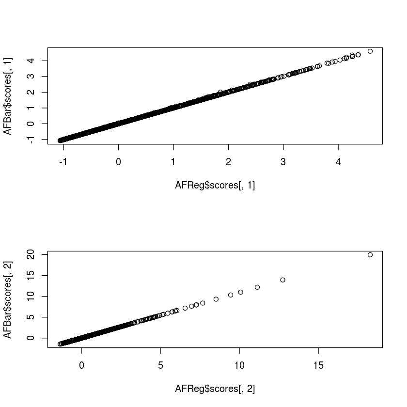

```r
# Escores fatoriais
AFReg <- factanal(pnad,factors=2, rotation = "varimax",scores="regression")
AFBar <- factanal(pnad,factors=2, rotation = "varimax",scores="Bartlett")
par(mfrow=c(2,1))
plot(AFReg$scores[,1],AFBar$scores[,1])
plot(AFReg$scores[,2],AFBar$scores[,2])
```

**Análise de Componentes Principais**

```
## Formúla
prcomp(formula, data = NULL, subset, na.action, ...)

## Padrão
prcomp(x, retx = TRUE, center = TRUE, scale. = FALSE,
       tol = NULL, rank. = NULL, ...)
```

```r
# Análise de componentes principais:
ACP=prcomp(pnad, scale = TRUE)
summary(ACP)
```

```
Importance of components:
                          PC1    PC2    PC3    PC4     PC5     PC6    PC7
Standard deviation     1.5788 1.5228 1.1403 1.1061 1.06198 0.99738 0.9284
Proportion of Variance 0.1917 0.1784 0.1000 0.0941 0.08675 0.07652 0.0663
Cumulative Proportion  0.1917 0.3701 0.4702 0.5643 0.65101 0.72753 0.7938
                           PC8     PC9    PC10    PC11    PC12    PC13
Standard deviation     0.88185 0.85242 0.78638 0.63617 0.36222 0.14710
Proportion of Variance 0.05982 0.05589 0.04757 0.03113 0.01009 0.00166
Cumulative Proportion  0.85365 0.90954 0.95711 0.98824 0.99834 1.00000
```

```r
ACP
```

```
Standard deviations (1, .., p=13):
 [1] 1.5787765 1.5228432 1.1403366 1.1060573 1.0619775 0.9973766 0.9283941
 [8] 0.8818456 0.8524228 0.7863751 0.6361681 0.3622155 0.1471017

Rotation (n x k) = (13 x 13):
                    PC1         PC2         PC3          PC4         PC5
sexo        -0.04593924  0.05993525 -0.20973958 -0.630753835  0.30585945
idade       -0.58263016  0.07946650  0.03973905  0.067235245  0.08438757
analfabeto  -0.24502860  0.32648567  0.14448262  0.014505285 -0.37573760
educ         0.10395001 -0.49660023 -0.08153644  0.023469122  0.30824010
ativ        -0.03006519  0.20088435 -0.11901348 -0.666660275 -0.16757192
ren_fam     -0.16733289 -0.52372745  0.14763010 -0.182016834 -0.35617512
componentes  0.26670781  0.09237708  0.10609681 -0.051221359 -0.44048466
peso        -0.04613456  0.01073409 -0.27785721 -0.036987233  0.19094905
ida2        -0.58037183  0.11058106  0.03372873 -0.008401525  0.04605542
per_capita  -0.21997916 -0.51430272  0.13114625 -0.172598555 -0.27423160
negro       -0.04497607  0.06080822 -0.59532281  0.220373107 -0.37879600
pardo        0.11769701  0.18026480  0.65268532 -0.075314763  0.10486823
migrante    -0.29038539 -0.02580620  0.06117462  0.176670932  0.21424483
                     PC6         PC7         PC8          PC9        PC10
sexo         0.200004183 -0.14066131  0.15971274 -0.582076615 -0.02279057
idade        0.039665522 -0.00831309 -0.36509178 -0.095636861  0.03686794
analfabeto  -0.166445476  0.12245570  0.43992010 -0.328619483 -0.26441601
educ         0.130902870 -0.02244384 -0.17145282 -0.131219945  0.04446228
ativ         0.053071739  0.01455753 -0.05234492  0.601741616  0.10906040
ren_fam     -0.079249555 -0.07553936  0.04699968 -0.046003108  0.03568831
componentes -0.012618583 -0.65651878 -0.44072870 -0.207879853 -0.10718268
peso        -0.885053926 -0.21109230  0.01781865 -0.024641778  0.22830853
ida2         0.032231996  0.01343741 -0.38501792 -0.009963514  0.03482717
per_capita  -0.096083481  0.09092322  0.17242155 -0.002681072  0.10318744
negro        0.255284459  0.02020779  0.08157072 -0.145496064  0.59330361
pardo       -0.001589409  0.02596046  0.02817910 -0.139295326  0.69542545
migrante     0.213459398 -0.68820148  0.48306312  0.279502604  0.04428964
                   PC11         PC12         PC13
sexo         0.18450104 -0.009252684  0.012327910
idade       -0.01904360  0.002943789 -0.703700707
analfabeto  -0.50641282  0.020463433  0.009759104
educ        -0.75373423  0.071628308  0.029913575
ativ        -0.29250924  0.013199420 -0.081052693
ren_fam      0.07601165 -0.701820873  0.002804424
componentes -0.05357041  0.171563571 -0.001608729
peso        -0.04100947 -0.010124182  0.002821990
ida2        -0.01203374  0.014823179  0.704610568
per_capita   0.18954982  0.686287072 -0.010350444
negro       -0.04548459 -0.015514520  0.009971026
pardo       -0.07672215 -0.023490335  0.007474513
migrante    -0.03327763  0.009532436  0.018353369
```

```r
# rotação
k <- 3
PCA =ACP$rotation[, 1:k] %*% diag(ACP$sdev[1:k])
CPA= varimax(PCA)
```

```r
CPA
```

```
$loadings

Loadings:
            [,1]   [,2]   [,3]
sexo                      -0.244
idade       -0.923
analfabeto  -0.431  0.471  0.126
educ         0.215 -0.743
ativ                0.308 -0.131
ren_fam     -0.242 -0.815  0.104
componentes  0.393  0.156  0.182
peso                      -0.323
ida2        -0.921  0.123
per_capita  -0.323 -0.804
negro               0.116 -0.679
pardo               0.253  0.771
migrante    -0.461

               [,1]  [,2]  [,3]
SS loadings    2.47 2.318 1.324
Proportion Var 0.19 0.178 0.102
Cumulative Var 0.19 0.368 0.470

$rotmat
            [,1]        [,2]       [,3]
[1,]  0.98940657  0.04778879 0.13707977
[2,] -0.05275905  0.99806665 0.03285497
[3,] -0.13524465 -0.03973912 0.99001499
```

**Análise gráfica**

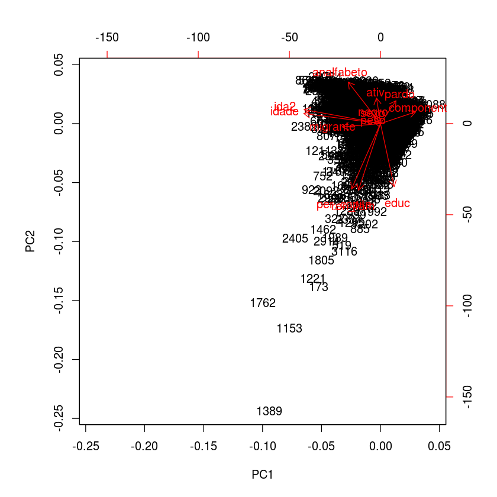

```r
biplot(ACP)
```

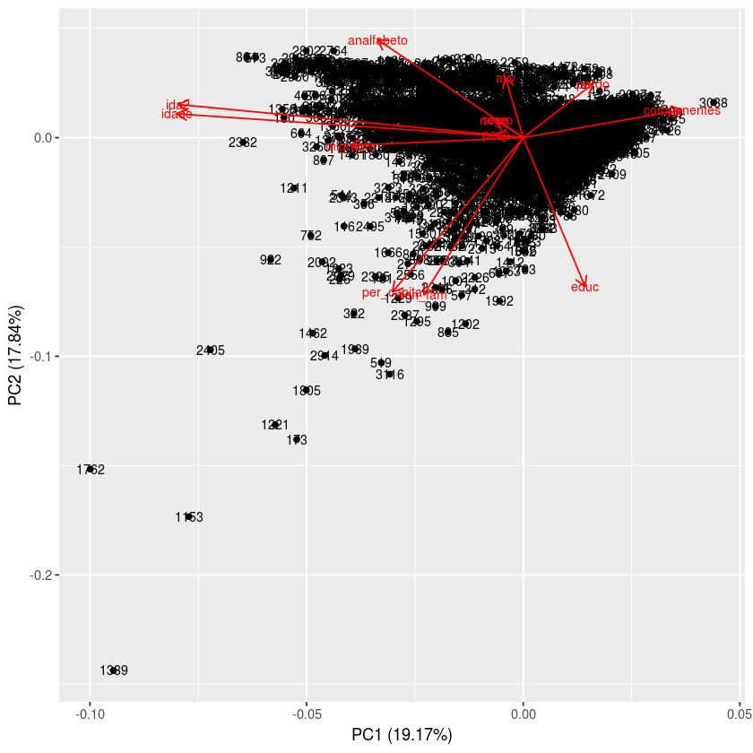

```r
library(ggfortify)
autoplot(ACP, label = TRUE, label.size = 3,
         loadings = TRUE, loadings.label = TRUE, loadings.label.size  = 3)
```

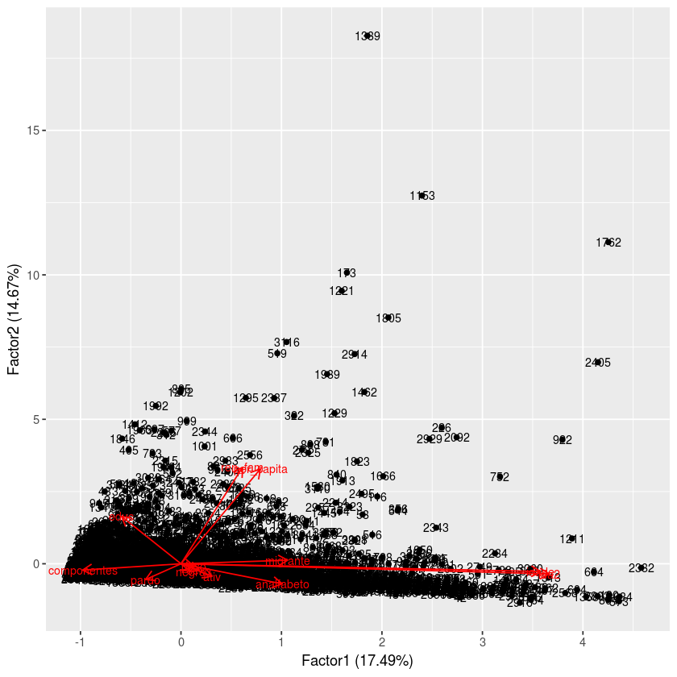

```r
autoplot(AFReg, label = TRUE, label.size = 3,
         loadings = TRUE, loadings.label = TRUE, loadings.label.size  = 3)
```

**Análise de cluster**

Outra ferramenta importante em multivariada é a análise de cluster. Para este é necessário uma biblioteca adcional a MVar.pt...

```
Cluster(Data, Titles = NA, Hierarquico = TRUE, Analise = "Obs",
        CorAbs = FALSE, Normaliza = FALSE, Distance = "euclidean",
        Method = "complete", Horizontal = FALSE, NumGrupos = 0,
        Casc = TRUE)
```

- Distance: Metrica das distancias caso agrupamentos hierarquicos: "euclidean" (default), "maximum", "manhattan", "canberra", "binary" ou "minkowski". Caso Analise = "Var" a metrica sera a matriz de correlacao, conforme CorAbs.
- Method: Metodo para analises caso agrupamentos hierarquicos: "complete" (default), "ward.D", "ward.D2", "single", "average", "mcquitty", "median" ou "centroid".

```r
library(MVar.pt)

pnad2<-pnad[1:600,c(1,2,4,7,10)]
Res <- Cluster( pnad2, Analise = "Obs", CorAbs = TRUE,
       Normaliza = TRUE,  Horizontal = FALSE, NumGrupos = 3, Hierarquico = TRUE,
       Distance = "manhattan",  Method = "ward.D")
```

[figure not shown]

```r
print("Tabela com as similaridades e distancias:"); Res$TabRes
print("Grupos formados:");table(Res$Groups$Grupos)
print("Tabela com os resultados dos grupos:"); Res$ResGroups
print("Soma do quadrado total:"); Res$SQT
#print("Matriz de distancias:"); Res$MatrixD

#write.table(file="Exemplo/TabelaSimilaridade.csv", Res$TabRes, sep=";",dec=",",row.names = FALSE)
```

```
[1] "Tabela com as similaridades e distancias:"
```

A matrix: 4 × 4 of type dbl

| Passos | Grupos | Similaridade | Distancia |
| --- | --- | --- | --- |
| 1 | 4 | -477.463 | 125.79 |
| 2 | 3 | -762.545 | 187.89 |
| 3 | 2 | -932.536 | 224.92 |
| 4 | 1 | -2541.500 | 575.39 |

```
[1] "Grupos formados:"
```

```
  1   2   3
286 207 107
```

```
[1] "Tabela com os resultados dos grupos:"
```

A matrix: 3 × 8 of type dbl

| Grupos | Qtd.Elementos | Soma Quadrados | Media sexo | Media idade | Media educ | Media componentes | Media per_capita |
| --- | --- | --- | --- | --- | --- | --- | --- |
| 1 | 286 | 883.1906 | 1.0159602 | -0.03490805 | 0.06117809 | -0.0472778 | -0.1615823 |
| 2 | 207 | 587.0063 | -0.9826500 | -0.06240404 | -0.66111201 | 0.2496948 | -0.2360269 |
| 3 | 107 | 597.3691 | -0.8145426 | 0.21403120 | 1.11545096 | -0.3566858 | 0.8885057 |

```
[1] "Soma do quadrado total:"
```

2995

«

## 5.4 Funções e estruturas de controle e repetição

### 5.4.1 Funções

Não é raro a necessidade de escrever funções simples a fim de simplificar rotinas de trabalho. Apesar do R ter um número elevado de pacotes e funções, instalar pacotes para rotinas relativamente simples pode ser desnecessário. Podendo o próprio usuário construir a sua função. A estrutura básica:

> `personalfunction<-function(argumentos){`

> > `expressão'

> > `saída`

> `}`

**Exemplos**

```r
estattabble<-function(x) {
    a1 <- mean(x)
    a2 <- median(x)
    a3 <- sd(x)
    a5 <- max(x)
    a4 <- min(x)
    d <- data.frame(c(a1,a2,a3,a4,a5))
    rownames(d) <-c("Média", "mediana", "sd",  "minimo", "maximo")
    colnames(d) <-c("estatisticas da variável")
 d
 }
estattabble(ipca$ipca)
```

|  | estatisticas da variável |
| --- | --- |
| Média | 0.5233889 |
| mediana | 0.4700000 |
| sd | 0.3862875 |
| minimo | -0.2100000 |
| maximo | 3.0200000 |

```r
esfera<-function(raio) {
    V = (4/3)*pi*raio^3
    A = (4)*pi*raio^2
   d <- data.frame( c(V,A))
    rownames(d) <-c("Volume", "Área")
    colnames(d) <-c(paste("Para esfera de raio ",raio,":"))
 d
 }

circulo<-function(raio) {
    C = 2*pi*raio
    A = pi*raio^2
    d <- data.frame( c(C,A))
    rownames(d) <-c("Circunferência", "Área")
    colnames(d) <-c(paste("Para o circulo de raio ",raio,":"))
 d
 }

esfera(2)
circulo(2)
```

|  | Para esfera de raio 2 : |
| --- | --- |
| Volume | 33.51032 |
| Área | 50.26548 |

|  | Para o circulo de raio 2 : |
| --- | --- |
| Circunferência | 12.56637 |
| Área | 12.56637 |

#### **Equação Black-Scholes**

A equação de Black-Scholes descreve o preço de uma opção ao longo do tempo. Por exemplificação, usaremos a fórmula final definida por:

\begin{equation} \mathrm C(\mathrm S,\mathrm t)= \mathrm N(\mathrm d_1)\mathrm S - \mathrm N(\mathrm d_2) \mathrm K \mathrm e^{-rt} \label{eq:2} \end{equation}\begin{equation} \mathrm d_1= \frac{1}{\sigma \sqrt{\mathrm t}} \left[\ln{\left(\frac{S}{K}\right)} + t\left(r + \frac{\sigma^2}{2} \right) \right] \end{equation}\begin{equation} \mathrm d_2= d_1 - {\sigma \sqrt{\mathrm t}} \end{equation}\begin{equation} N(x)=\frac{1}{\sqrt{2\pi}} \int_{-\infty}^{x} \mathrm e^{-\frac{1}{2}z^2} dz \label{eq:5} \end{equation}

Notação:

```r
# Black sholes
#S= stock.price
#K= strike.price
#t= years.maturity
#r= risk.free rate
#v= Volatility (desvio padrão)

Black.Scholes <- function(S,K,t,r,v) {
    d1 <- (log(S/K)+t*(r+(v^2)/2))/(v*sqrt(t))
    d2 <- d1-v*sqrt(t)

    cp = S*pnorm(d1)-pnorm(d2)*K*exp(-r*t)
    pp = K*exp(-r*t)*pnorm(-d2)-S*pnorm(-d1)

    tb <-  data.frame(c( cp,pp,d1,d2))
    rownames(tb) <- c("call.price", "put.price", "d1", "d2")
    tb
}
```

```r
Black.Scholes(10,12, 1, .06, 2)
```

|  | c.cp..pp..d1..d2. |
| --- | --- |
| call.price | 6.6300789 |
| put.price | 7.9312533 |
| d1 | 0.9388392 |
| d2 | -1.0611608 |

### 5.4.2 Estruturas de controle

Em programação, controles são estruturas que permitem controlar o fluxo de um programa, as estruturas básicas são:

- if e else: para testar condições lógicas;

  ```
  if(x > 3) {y <- 10 } else { y <- 0 }
  y <- if(x > 3) { 10 } else { 0 }
  ```

- ifelse() : para testar condições lógicas;

  ```
  ifelse(x > 3, TRUE, FALSE)
  ifelse(x > 3, X<- 3, x <- 0)
  ```

```r
x <-5
  if(x > 3) {
      y <- 10
      cat(y)
  } else {
      y <- 0
      cat(y)
  }
```

```
10
```

```r
y <- ifelse(x > 3,10,0)
cat(y)
```

```
10
```

```r
y1 <- if(x > 3) { 10 } else { 0 }
 y2 <- ifelse(x > 3,  10 , 0 )
 y1==y2
```

TRUE

### 5.4.3 Estruturas de repetição

Por vezes serão necessários repetir comandos, linhas de comandas ou mesmo funções.

Na maioria das vezes será muito melhor que esta repetição seja feita por estruturas de repetição ao invez de escrever o mesmo comando repetidamente.

- for: quando o loop tem um número fixo de repetições:

  ```
    for(i in 1:10) { print(i)}`
    x <- c("a", "b", "c", "d");  for( y in x) {print(y)}
  ```

- while: quando não se sabe a dimenssão do loop:

  ```
    x <- 1000;
    while(x < 10000) {
    print(x)
    x <- x + 1000
    }
  ```

- repeat: similar a while, repete de forma infinita até que a função break seja executada;
- break: permite sair de qualquer tipo de loop;

  ```
    x<- 1
    y<- 2

    repeat {
        xi<- rnorm(1)
        if(abs(xi - x) >y) {
            break
        }else {
        x<- xi
        }
    }
  ```

- next: ignora a interação de um loop;

  ```
    for(i in 1:100) {
          if(i > 2 & i< 10 ) {
            ## não executa ações no loop 3 a 9
            next
        }
        ## execução
    }
  ```

Estas estruturas são utilizadas com frenquência em rotinas de programação, mas não são as únicas, apenas as mais relevantes neste curso.

```r
boletim <- function(){
  cat("precione enter uma vez para o próximo nome ou duas vezes para finalizar")
     nomes <- scan(what = "character")
  cat("precione enter uma vez para a próxima nota ou duas vezes para finalizar")
      notas <- scan()

  a<- length(notas)

  notas <- data.frame(nomes, notas)
  for  (i in c(1:a)) {
    notas[i,3] <- ifelse(notas[i,2]>= 70, "Aprovado", "Reprovado")
    notas[i,4] <- ifelse(notas[i,2]>= 70, "C","R")
    notas[i,4] <- ifelse(notas[i,2]>= 80, "B", notas[i,4])
    notas[i,4] <- ifelse(notas[i,2]>= 90, "A", notas[i,4])
  }
  names(notas) <- c("Aluno", "Nota", "Status", "Conceito")
  print(notas)

}
```

#### Exercício.

Reescreva a função boletim() trocando a estrtura de repetição "for" por "while" e depois por "repeat".

### 5.4.4 Transformando, aplicando, replicando tabelas e matrizes

```
A família de funções "apply" tem como objetivo replicar, de maneira eficiente, ações em diferentes objetos. É quase sempre uma alternativa mais rápida e eficiente ao clássico loop quando estamos trabalhando com matrizes, tabelas e listas.
```

- Funções da família apply:
  - apply()
  - mapply()
  - tapply()
  - lapply()
  - sapply()
  - vapply()
  - rapply()
- funções relacionadas
  - rep()
  - aggregate()
  - Sweep()
- **apply**

Replica determinada função por linha ou coluna de uma array.

```r
A1 <- matrix(round(runif(25)*10,0), nrow=5, ncol =5 )
A1
```

A matrix: 5 × 5 of type dbl

| 4 | 0 | 7 | 10 | 1 |
| --- | --- | --- | --- | --- |
| 10 | 8 | 1 | 8 | 1 |
| 8 | 4 | 9 | 5 | 9 |
| 7 | 7 | 7 | 7 | 4 |
| 3 | 5 | 7 | 3 | 1 |

```r
apply(X = A1,MARGIN = 1, FUN = mean)
mean(A1[2,])

apply(A1,2, mean)
mean(A1[,3])
```

1. 4.4

2. 5.6

3. 7

4. 6.4

5. 3.8

5.6

1. 6.4

2. 4.8

3. 6.2

4. 6.6

5. 3.2

6.2

- **rep**

Replica um objeto (básico) determinadas vezes.

```r
rep(1,5)
rep("casa",5)
rep(1:5,2)
```

1. 1

2. 1

3. 1

4. 1

5. 1

1. 'casa'

2. 'casa'

3. 'casa'

4. 'casa'

5. 'casa'

1. 1

2. 2

3. 3

4. 4

5. 5

6. 1

7. 2

8. 3

9. 4

10. 5

```r
6*4*2+5*4+10
```

78

- **mapply**

Aplica derterminada a função a todos os elementes de um ou mais objetos do tipo matriz ou tabela.

```r
mapply(sqrt,A1)
```

1. 2

2. 3.16227766016838

3. 2.82842712474619

4. 2.64575131106459

5. 1.73205080756888

6. 0

7. 2.82842712474619

8. 2

9. 2.64575131106459

10. 2.23606797749979

11. 2.64575131106459

12. 1

13. 3

14. 2.64575131106459

15. 2.64575131106459

16. 3.16227766016838

17. 2.82842712474619

18. 2.23606797749979

19. 2.64575131106459

20. 1.73205080756888

21. 1

22. 1

23. 3

24. 2

25. 1

```r
mapply(rep,1:5,5)
```

A matrix: 5 × 5 of type int

| 1 | 2 | 3 | 4 | 5 |
| --- | --- | --- | --- | --- |
| 1 | 2 | 3 | 4 | 5 |
| 1 | 2 | 3 | 4 | 5 |
| 1 | 2 | 3 | 4 | 5 |
| 1 | 2 | 3 | 4 | 5 |

```r
mapply(function(x, y) x^2+y,
       c(1, 2, 3),
       c(4, 5, 6))
mapply(function(x, y) c(x^3, y^2),
       c(1, 2, 3),
       c(4, 5, 6))
```

1. 5

2. 9

3. 15

A matrix: 2 × 3 of type dbl

| 1 | 8 | 27 |
| --- | --- | --- |
| 16 | 25 | 36 |

- **tapply**

Aplica determinada função a um conjunto de dados (matrix, data.frame) condicionados a outra variável.

```r
n<- 20
fac <- data.frame(sexo = factor(rep_len(1:2, n), levels = 1:2, labels =  c("Homem", "Mulher")),
                  renda = round(rnorm(20,2000,50),2)
                 )
table(fac$sexo)
tapply(fac$renda, fac$sexo, sum)
```

```
 Homem Mulher
    10     10
```

**Homem**

20065.76

**Mulher**

20362.73

«

## 5.5 Regressão simples

Estimando um modelo semples de MQO com base nos dados da PNAD.

```r
library(foreign)
pnad <-  read.dta('Exemplo/pnad_mod.dta')
pnad2 <- pnad[,c(18,3,8,13,21)]
pnad2 <- na.omit(pnad2)
pnad2[1:5,]
```

A data.frame: 5 × 5

|  | lnrenda <dbl> | idade <int> | educ <int> | componentes <int> | negro <int> |
| --- | --- | --- | --- | --- | --- |
| 1 | 6.109248 | 23 | 12 | 3 | 0 |
| 2 | 6.551080 | 36 | 8 | 2 | 0 |
| 6 | 6.551080 | 48 | 5 | 3 | 0 |
| 8 | 8.006368 | 24 | 15 | 4 | 0 |
| 9 | 6.095825 | 31 | 14 | 4 | 0 |

```r
pnad2 <- na.omit(pnad2)
result <- lm(pnad2, lnrenda =~ idade+educ+componentes+negro)
# estraindo estaísticas dos resultados
 summary(result)
 DegreesOfFreedom <- result$df
 Yhat <- result$fitted.values
 Coef <- result$coefficients
 Resid <- result$residuals
 RSquared <- result$r.squared
 aic <- AIC(result)
 bic <- BIC(result)
```

```
Call:
lm(formula = pnad2, lnrenda = ~idade + educ + componentes + negro)

Residuals:
    Min      1Q  Median      3Q     Max
-3.4756 -0.4307  0.0232  0.4814  3.3565

Coefficients:
            Estimate Std. Error t value Pr(>|t|)
(Intercept)  4.85260    0.09870  49.167   <2e-16 ***
idade        0.01921    0.00161  11.928   <2e-16 ***
educ         0.12215    0.00469  26.048   <2e-16 ***
componentes -0.03496    0.01375  -2.544   0.0111 *
negro       -0.06712    0.07094  -0.946   0.3442
---
Signif. codes:  0 ‘***’ 0.001 ‘**’ 0.01 ‘*’ 0.05 ‘.’ 0.1 ‘ ’ 1

Residual standard error: 0.809 on 1623 degrees of freedom
Multiple R-squared:  0.3229,	Adjusted R-squared:  0.3213
F-statistic: 193.5 on 4 and 1623 DF,  p-value: < 2.2e-16
```

Outros modelos em Cross Sectional data podem ser estimados pelo comando glm(). Como segue na tabela abaixo.

**GLM Family link**

| Family | identity | logit | probit | cloglog | sqrt | inverse | log | 1/mu² | cauchit |
| --- | --- | --- | --- | --- | --- | --- | --- | --- | --- |
| gaussian | sim* | - | - | - | - | sim | sim | - | - |
| binomial | - | sim* | sim | sim | - | - | sim | - | sim |
| poisson | sim | - | - | - | sim | - | sim* | - | - |
| Gamma | sim | - | - | - | - | sim* | sim | - | - |
| inverse.gaussian | sim | - | - | - | sim | sim | sim | sim* | - |
| quasi | sim | sim | sim | sim | sim | sim | sim | sim | - |

**variance link option: *"constant", "mu(1-mu)", "mu", "mu^2", "mu^3", "Binomial()", "binary", "NegativeBinomial()", nbinom***

Para mais opções ver `glmer` e `brms`.

```r
pnad2$dr<-pnad2$lnrenda>mean(pnad2$lnrenda)
table(pnad2$dr)
```

```
FALSE  TRUE
  892   736
```

```r
h <- glm(dr~idade+educ+componentes+negro, data = pnad2, family=binomial(link="logit"))
summary(h)
```

```
Call:
glm(formula = dr ~ idade + educ + componentes + negro, family = binomial(link = "logit"),
    data = pnad2)

Deviance Residuals:
    Min       1Q   Median       3Q      Max
-2.3817  -0.9262  -0.4950   0.9618   2.4103

Coefficients:
             Estimate Std. Error z value Pr(>|z|)
(Intercept) -3.544731   0.304081 -11.657   <2e-16 ***
idade        0.043161   0.004802   8.989   <2e-16 ***
educ         0.248164   0.015334  16.184   <2e-16 ***
componentes -0.083489   0.039808  -2.097    0.036 *
negro       -0.021398   0.197521  -0.108    0.914
---
Signif. codes:  0 ‘***’ 0.001 ‘**’ 0.01 ‘*’ 0.05 ‘.’ 0.1 ‘ ’ 1

(Dispersion parameter for binomial family taken to be 1)

    Null deviance: 2241.9  on 1627  degrees of freedom
Residual deviance: 1856.2  on 1623  degrees of freedom
AIC: 1866.2

Number of Fisher Scoring iterations: 4
```

Podemos montar nossa própria regressão manualmente

```r
MQO = function(T) {
# Curso introdução ao R Econs
# Por: ANDRE SURIANE
#                  UFJF
#                  Faculdade de Economia
#                  laboratório de estudos econômicos Econs
# estimar uma regressão linear simples passo a passo
# T é um data frame em que a primeira coluna é a variável a dependente e todas
# as demais são explicativas <<não deve conter a constante>>
     T <- na.omit(T)
     N <- nrow(T)  # numero de linas
     K <- ncol(T)  #  numero de variaveis
     DEP <- as.matrix(T[1])  # variavel dependente
     intercept <- matrix(1, nrow = N) # constante
     X <- data.frame(intercept, T[,2:K])
     X <- as.matrix(X)
     b <- solve(t(X)%*%X)%*%(t(X)%*%DEP) # estimativas para b do MQO
     N <- nrow(T)
     k <-length(b)
     df <- N-K
     DEPc <- X%*%b # DEPUEL calculado
     er <- DEP-DEPc # erro
     sigma2 <- (t(er)%*%er)/N # variancia
     varR <- (t(er)%*%er)/df # variancia residual
     varR <- varR[1,1]
     MVC <- varR*(solve(t(X)%*%X)) # Matriz de variancia-convariancia
     media <- sum(DEP)/N # media da variavel dependente
     desvioT <- DEP-media # desvio total
     desvioE <- DEPc-media # desvio explicado
     R2 <- (t(desvioE)%*%desvioE)/(t(desvioT)%*%desvioT) # R2
     erm <-  (t(er)%*%er)*(N-1) # numerador dos R2 ajustado
     ern <- (t(desvioT)%*%desvioT)*df # denominador do R2 ajustado
     R2ajus <- 1-(erm/ern) # R2 ajustado

     ## critérios de ajustamento
     AIC <- N*(log(2*pi)+1+log((sum(er^2)/N)))+((K+1)*2) # criterio Akaike by residuls
     BIC <- AIC + K*(log(N)-2)
     ll <-0.5*(sum(log(intercept))-N*(log(2*pi)+1-log(N)+log(sum(intercept*er^2)))) #  likelihood function
     AKI <- 2*K-2*ll # AIC by  likelihood function
     AICc1 <- AKI +K*(K+1)/(N-K-1)
     AICc2 <- AIC +K*(K+1)/(N-K-1)
     SC <- log(N)*K-2*ll # SBC by  likelihood function


     dp <- sqrt(diag(MVC)) # desvio padrao
     et <- b/dp  # estatistica T
     I <- (t(desvioE)%*%desvioE)/(K-1) # numerador da estatistica F
     O <- (t(er)%*%er)/(N-K) # denomindaor da estatistica F
     ef <- I/O # estatistica F
     pval <- 1-pf(ef,K, N) # Pvalor estatistica F

     res <- data.frame(b, dp, et )
     for (i in 1:K) {
     res[i,4]<- 2*(min(1-pt(q=res[i,3], df=N-K), pt(q=res[i,3], df=N-K))) # Pvalor  estatistica t
                 }
     res <- round(res, 4)
     colnames(res) <- c("Betas", "Des.Pad.", "Estat-t"  , "P-valor")
     res$signif <-  ifelse(res[4]<0.001,"***", ifelse(res[4]<0.01, "**", ifelse(res[4]<0.05,"*","_")))

     res2 <- data.frame(R2, R2ajus, AIC, BIC, ef, pval)
     res2 <- round(res2, 4)
     res3 <- data.frame(AIC, AKI, AICc1, AICc2, BIC, SC)

     colnames(res2) <- c("R2", "R2ajus", "AIC", "BIC", "Esta_F", "Pvalor")
     rownames(res2) <- c("Estatisticas")

     return(list(res,res2,res3))

}
```

```r
pnad2$dr<- NULL
MQO(pnad2)
```

1. A data.frame: 5 × 5

   |  | Betas <dbl> | Des.Pad. <dbl> | Estat-t <dbl> | P-valor <dbl> | signif <chr[,1]> |
   | --- | --- | --- | --- | --- | --- |
   | intercept | 4.8526 | 0.0987 | 49.1675 | 0.0000 | *** |
   | idade | 0.0192 | 0.0016 | 11.9284 | 0.0000 | *** |
   | educ | 0.1222 | 0.0047 | 26.0478 | 0.0000 | *** |
   | componentes | -0.0350 | 0.0137 | -2.5438 | 0.0111 | * |
   | negro | -0.0671 | 0.0709 | -0.9462 | 0.3442 | _ |

2. A data.frame: 1 × 6

   |  | R2 <dbl> | R2ajus <dbl> | AIC <dbl> | BIC <dbl> | Esta_F <dbl> | Pvalor <dbl> |
   | --- | --- | --- | --- | --- | --- | --- |
   | Estatisticas | 0.3229 | 0.3213 | 3936.981 | 3963.956 | 193.5208 | 0 |

3. A data.frame: 1 × 6

   | AIC <dbl> | AKI <dbl> | AICc1 <dbl> | AICc2 <dbl> | BIC <dbl> | SC <dbl> |
   | --- | --- | --- | --- | --- | --- |
   | 3936.98 | 3934.98 | 3934.999 | 3936.999 | 3963.956 | 3961.956 |

```r
AIC(result)
BIC(result)
```

3936.98045272556

3969.35109800494

«

# 6 Gráficos

A próxima etapa no nosso aprendizado é criar gráficos. Já vimos uma série de objetos dentro do R, mas ainda não colocamos os mesmos de forma gráfica.

Para verificar as opções de gráficos no R, acesse o link [R Graph Gallery](https://www.r-graph-gallery.com)

[figure not shown]

## 6.1 Linhas e pontos

O comando básico para a geração de um gráfico é o plot(). Segue abaixo o exemplo de um gráfico simples.

**Exemplo:**

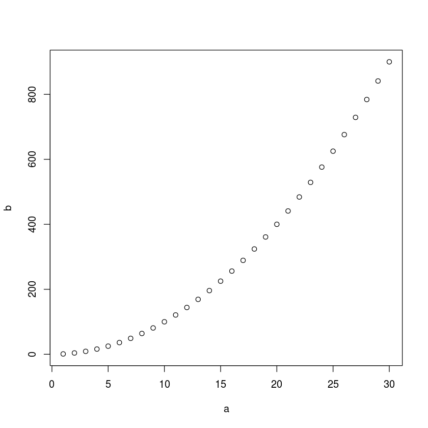

```r
a <- 1:30
 b <- a^2
 plot(a,b)
```

Exemplo de gráfico simples com atribuição de pontos em coordenadas cartesianas

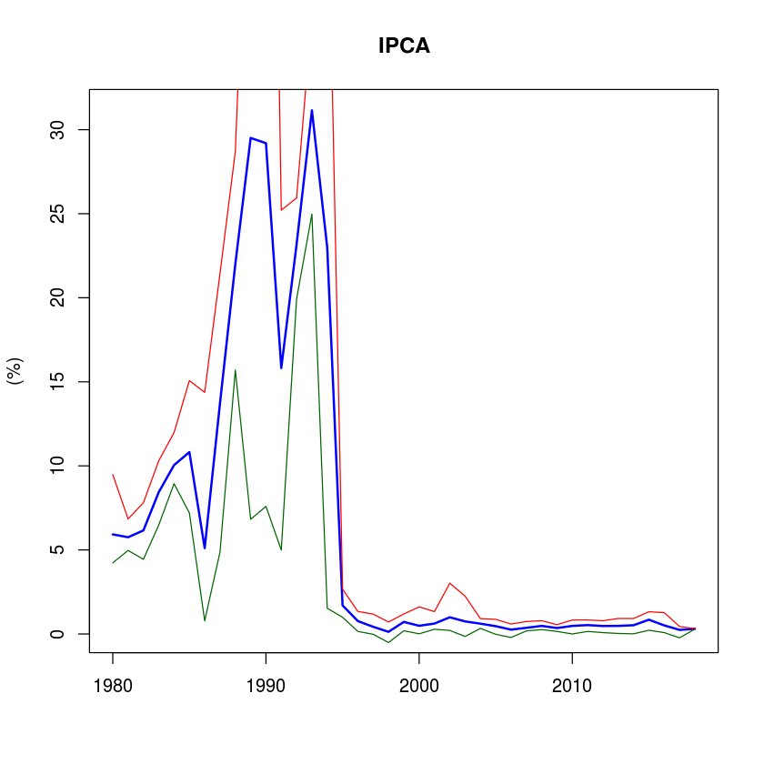

```r
datacsv <- read.csv2("Exemplo/Exemplo1_ipca.csv",header =T, sep=";", dec=".")
ipca <- datacsv
colnames(ipca)<- c("data", "ipca12")
ipca$ano <- floor(ipca[,1])
ipca$min <- ave(ipca$ipca12, ipca$ano, FUN = min)
ipca$max <- ave(ipca$ipca12, ipca$ano, FUN = max)
ipca$mean <- ave(ipca$ipca12, ipca$ano, FUN = mean)

ipca2 <- aggregate(x = ipca,
              by = list(ipca$ano),
              FUN = mean)

plot(ipca2$ano, ipca2$mean, xlab='', ylab='(%)', type='l', col='blue', main='IPCA', lwd=2, lty=1) + # l define tipo linha
lines(ipca2$ano, ipca2$min, col="darkgreen")+
lines(ipca2$ano, ipca2$max, col="red")
#Exemplo de gráfico simples para a variável IPCA.
```

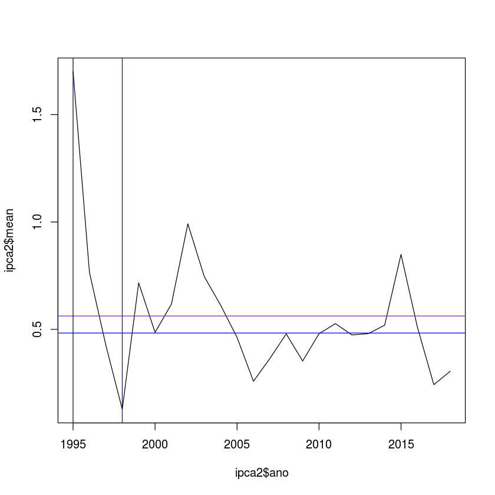

```r
ipca2<- subset(ipca2, ipca2$ano>1994)
plot(ipca2$ano, ipca2$mean, type="l", col ="black")+
abline(h = mean(ipca2$mean), col="purple3")
abline(h = median(ipca2$mean), col="blue")
abline(v =ipca2$ano[ipca2$mean==max(ipca2$mean)], col="darkblue")
abline(v =ipca2$ano[ipca2$mean==min(ipca2$mean)], col="blue")
```

Os gráficos gerados podem ser salvos imediatamente a sua criação. Existem vários formatos em que o R pode salvar essas imagens. Alguns deles são: JPEG, BMP, PDF, TIFF, PNG. No exemplo a seguir será utilizando o formato PNG, contudo a sintaxe para qualquer formato é a mesma.

```r
png(file="Imagens/plot.png",  width = 1200, height = 720, units = "px",bg = "white") # plot refere o nome da imagem
# alem de png() é possivel salvar em bmp() jpeg() tiff(), sem usar pacotes adcionais.
plot(a,b)   #grafico que estamos salvando
dev.off() #fecha a janela automaticamente
```

**png:** 2

**Scatter plot**

```r
#attach(Z)
png(file = "Imagens/sc1.png",  width = 1200, height = 720, units = "px",bg = "white")
plot( cos(x) ,cos(2*x) , cex = .5, col = "blue") +
points(sin(y),cos(2*y) , cex = .5, col = "red") +
points(x,y , cex = .5,  col = "darkgreen")
dev.off()
```

**png:** 2

**Linhas**

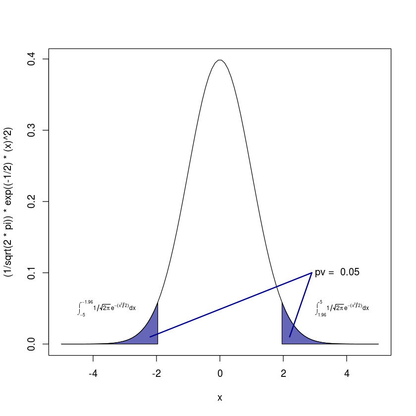

```r
# Gráfico de distribuição normal com 5% de significância
# definir x e fx
 x <- seq(-5, 5, l=100)
 fx <- function(x) (1/sqrt(2*pi))*exp((-1/2)*(x)^2)
 # plotar fx
 plot(x, (1/sqrt(2*pi))*exp((-1/2)*(x)^2), ty='l')

 # calcular integral
 ie1 <- integrate(fx, 1.96, 5)
 ie2 <- integrate(fx, -5, -1.96)
 pt <- as.numeric(ie1[1])+as.numeric(ie2[1])

 # definir intevalo de integração em x e valores de fx
 x <- seq(1.96, 5, l=100)
 fx1 <- (1/sqrt(2*pi))*exp((-1/2)*(x)^2)

 # plotar integral definida de fx
 polygon(rbind(cbind(rev(x),0),cbind(x,fx1)), col=adjustcolor('blue4', alpha = .6))

 x <- seq(-5, -1.96, l=100)
 fx2 <- (1/sqrt(2*pi))*exp((-1/2)*(x)^2)

 polygon(rbind(cbind(rev(x),0),cbind(x,fx2)), col=adjustcolor('blue4', alpha = .6))
# textos
 text(3, 0.05, expression(paste(integral(1/sqrt(2*pi)*e^{-(x^{2}/2)}*dx,1.96,5))),  adj = 0, cex = .6)
 text(-4.5, 0.05, expression(paste(integral(1/sqrt(2*pi)*e^{-(x^{2}/2)}*dx,-5,-1.96))),  adj = 0, cex = .6)
#https://stat.ethz.ch/R-manual/R-devel/library/grDevices/html/plotmath.html
text(3, 0.1, paste("pv = ",round(pt,2)), adj = 0, col = "black", cex = 1)
lines(c(2.9, 2.2), c(0.1, 0.01), col = 'blue4', lwd = 2)
lines(c(2.9, -2.2), c(0.1, 0.01), col = 'blue4', lwd = 2)
```

```r
exp(1)
```

2.71828182845905

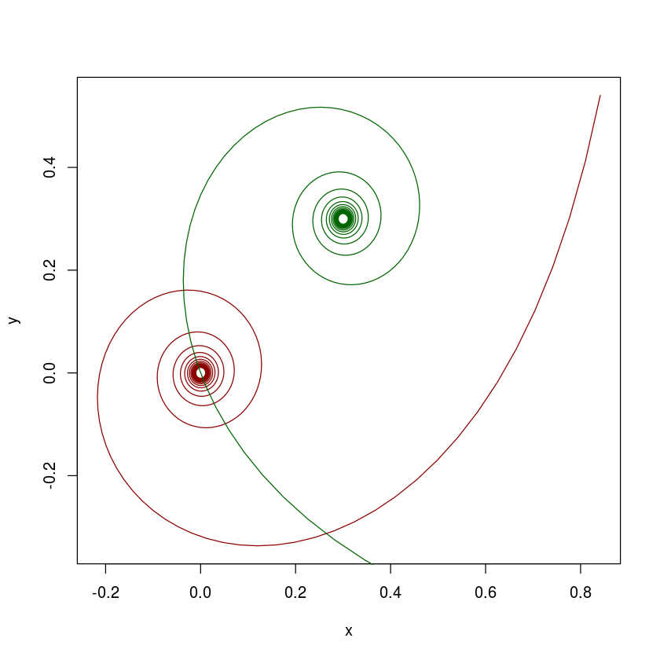

```r
t = 10:1000
x = sin(t/10)/(t/10)
y = cos(t/10)/(t/10)
plot(x,y,type = "l", col = "darkred") +
lines(y+.3,-x+.3, col = "darkgreen")
```

```r
esferaV<-function(raio) {
     (4/3)*pi*raio^3
 }
esferaA<-function(raio) {
    (4)*pi*raio^2
 }

circuloC<-function(raio) {
    2*pi*raio
 }

circuloA<-function(raio) {
   pi*raio^2
 }

esferaA(2)
circuloA(2)
```

50.2654824574367

12.5663706143592

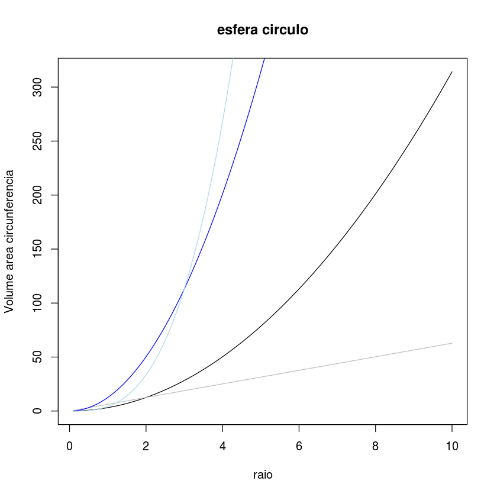

```r
pl <- data.frame(c(1:100)/10)
pl[,2]<- circuloA(1:100/10)
pl[,3]<- circuloC(1:100/10)
pl[,4]<- esferaA(1:100/10)
pl[,5]<- esferaV(1:100/10)
colnames(pl) <- c("raio","Área círculo", "circunferência", "Área esfera", "Volume")

plot(pl[,1:2], type="l", main="esfera circulo", ylab="Volume area circunferencia")+
lines(pl[,c(1,3)], col="gray")+
lines(pl[,c(1,4)], col="blue")+
lines(pl[,c(1,5)], col="lightblue")
```

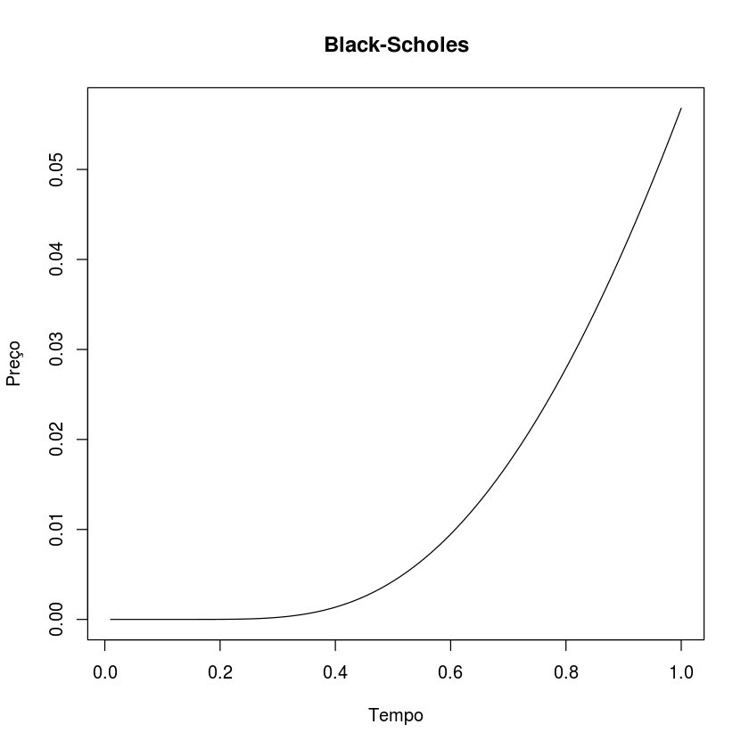

```r
pl <- data.frame(c(1:100)/100)
for (i in 1:100) paste(pl[i,2]<- Black.Scholes(10,12, pl[i,1], .06, .1)[1,1])

plot(pl[,1:2], type="l", main="Black-Scholes", xlab="Tempo", ylab="Preço")
```

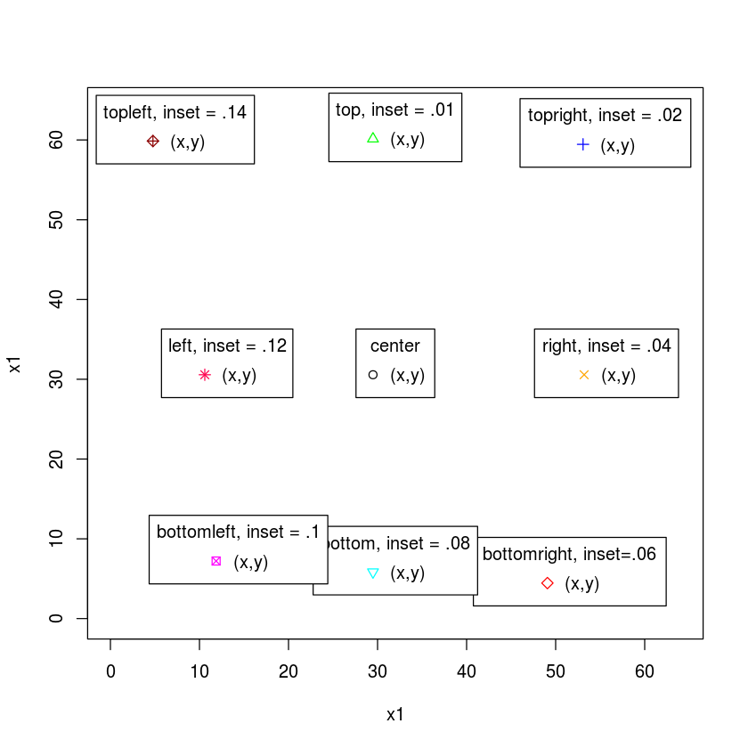

```r
x1 <- 0:64
plot(x1, x1, type= "n")
legend("center",      "(x,y)", pch = 1, title = "center")
legend("top",         "(x,y)", pch = 2, title = "top, inset = .01",       inset = .01, col="green")
legend("topright",    "(x,y)", pch = 3, title = "topright, inset = .02",  inset = .02, col="blue")
legend("right",       "(x,y)", pch = 4, title = "right, inset = .04",     inset = .04, col='orange')
legend("bottomright", "(x,y)", pch = 5, title = "bottomright, inset=.06", inset = .06, col='red')
legend("bottom",      "(x,y)", pch = 6, title = "bottom, inset = .08",    inset = .08, col="cyan")
legend("bottomleft",  "(x,y)", pch = 7, title = "bottomleft, inset = .1", inset = .1,  col="magenta")
legend("left",        "(x,y)", pch = 8, title = "left, inset = .12",      inset = .12, col="#FF004D")
legend("topleft",     "(x,y)", pch = 9, title = "topleft, inset = .14",   inset = .014, col="dark red")
#legend(posição, legenda, pch = "tipo de marcação [1,9]", title= "titulo", inset="deslocamento em direção ao centro, col = "cor")
```

«

## 6.2 Barras e histogramas

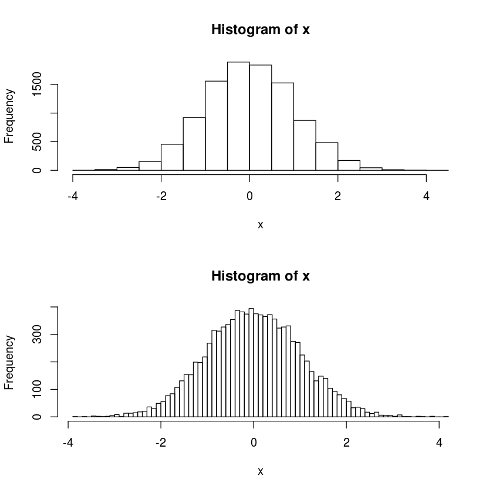

```r
x <- rnorm(1:10000)

par(mfrow=c(2,1))
hist (x, nclass = 20) # histograma com 20 classes
hist (x, nclass = 100) # histograma com 100 classes
```

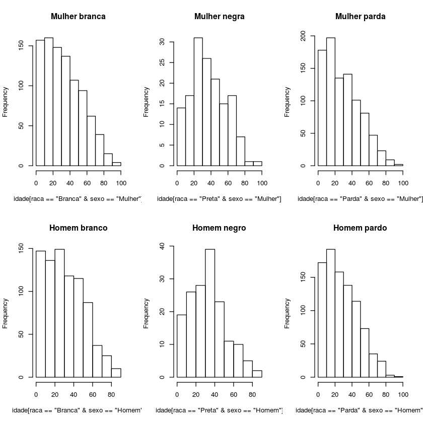

```r
par(mfrow=c(2,3))
hist(idade[raca=="Branca" & sexo == "Mulher"], main = "Mulher branca")
hist(idade[raca=="Preta"  & sexo == "Mulher"], main = "Mulher negra")
hist(idade[raca=="Parda"  & sexo == "Mulher"], main = "Mulher parda")
hist(idade[raca=="Branca" & sexo == "Homem"], main = "Homem branco")
hist(idade[raca=="Preta" & sexo == "Homem"], main = "Homem negro")
hist(idade[raca=="Parda" & sexo == "Homem"], main = "Homem pardo")
```

**Barras**

A função `barplot()` gera gráfico de barras, onde cada barra representa a medida de cada elemento de um vetor, ou seja, as barras são proporcionais com a “dimensão” do elemento.

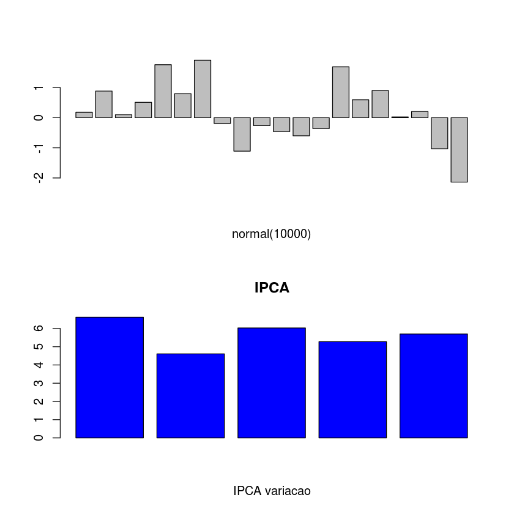

```r
# barplot(x, col=" ", legend.text=" ", xlab=" ",ylab=" ")
x <- rnorm(1:20)
ipca3 <-c (6.62 ,4.61 ,6.03 ,5.28 , 5.70)
par(mfrow=c(2,1))

barplot(x, xlab="normal(10000)")
barplot(ipca3,xlab="IPCA variacao",col="blue") + title("IPCA")
```

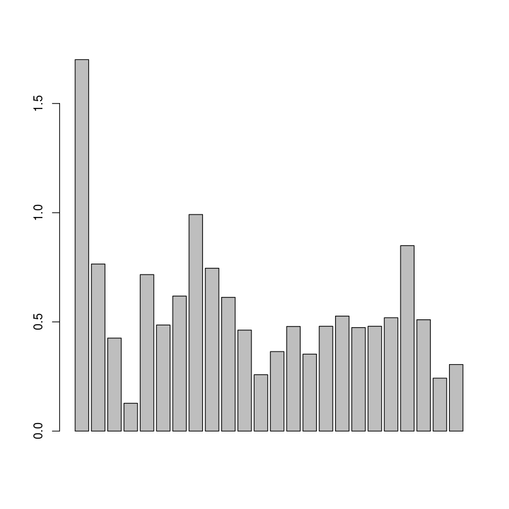

```r
barplot(ipca2$mean )
```

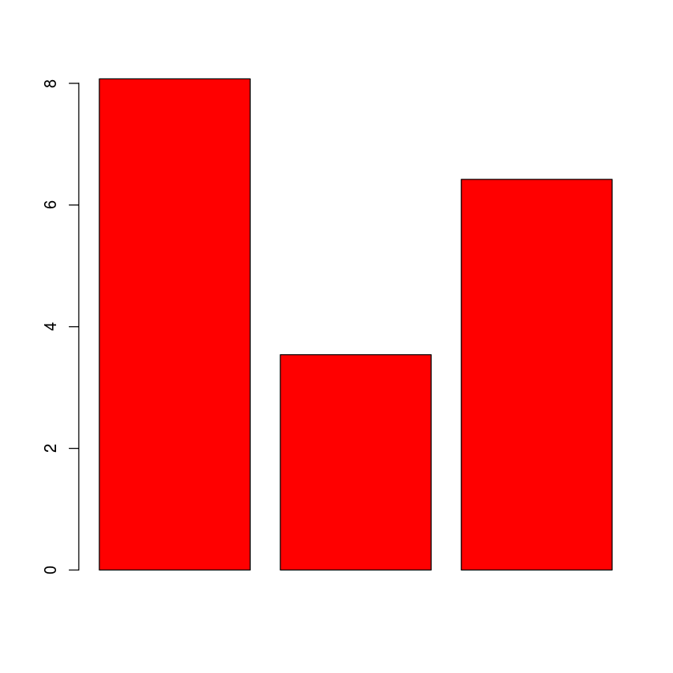

```r
barplot(c(mean(pnad2$educ), mean(pnad2$componentes), mean(pnad2$lnrenda)),col="red")
```

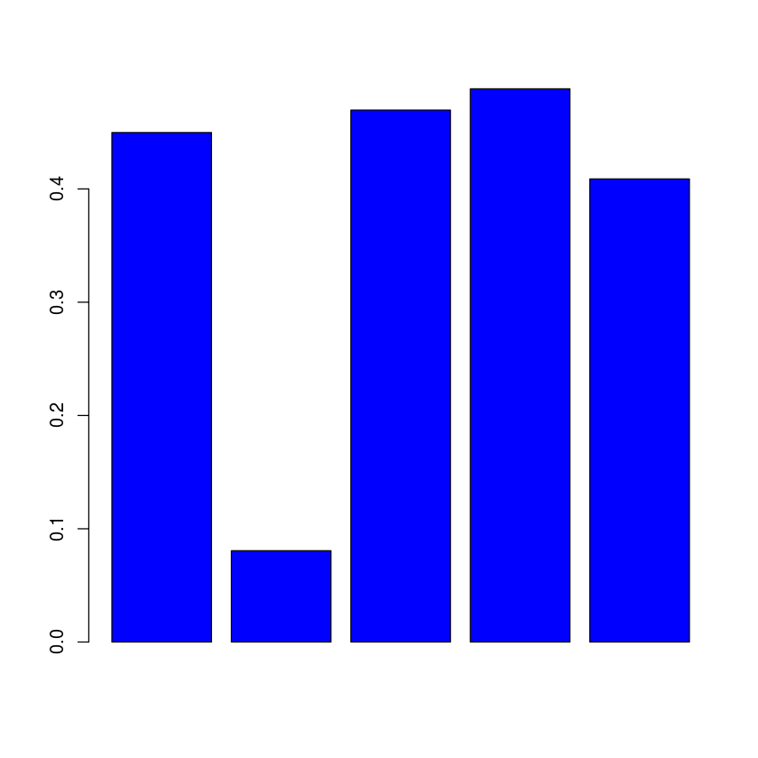

```r
barplot(c(mean(pnad$branco),mean(pnad$negro),mean(pnad$pardo),mean(pnad$masc),mean(pnad$migrante)),col="blue")
```

«

## 6.3 Gráficos para matrizes 2D e 3D

```r
input <- matrix(c(1:100)/10, 100,1)
pl = diag(100)
for (i in 1:100) {
    for (j in 1:100)  {
        pl[i,j]<- Black.Scholes(input[j,1], 12, input[i,1], .06, .1)[1,1]
        }
    }
```

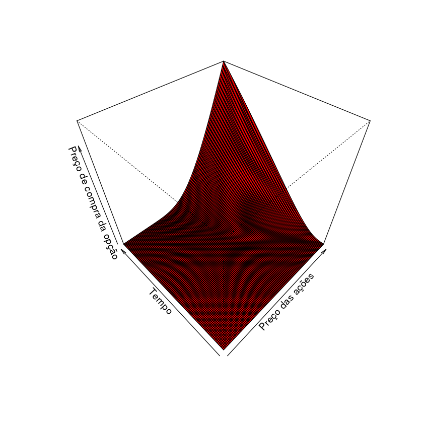

```r
persp(z = t(pl), xlab ="Preço das ações", ylab = "Tempo", zlab = "Preço de compra da opção", col = "red",
     phi= 45,
     theta = -45)
```

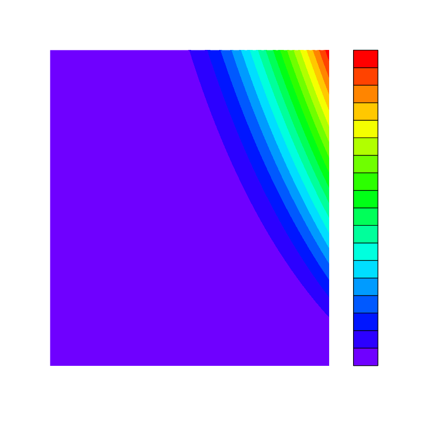

```r
tcol <- rev(rainbow(23)[1:18])
filled.contour(t(pl),nlevel=18, col =tcol, axes = FALSE )
```

**Para mais opções de cores clique na paleta**

[figure not shown]

```r
si = 40
data=matrix(2*rnorm(si*si)+10, si,si)
```

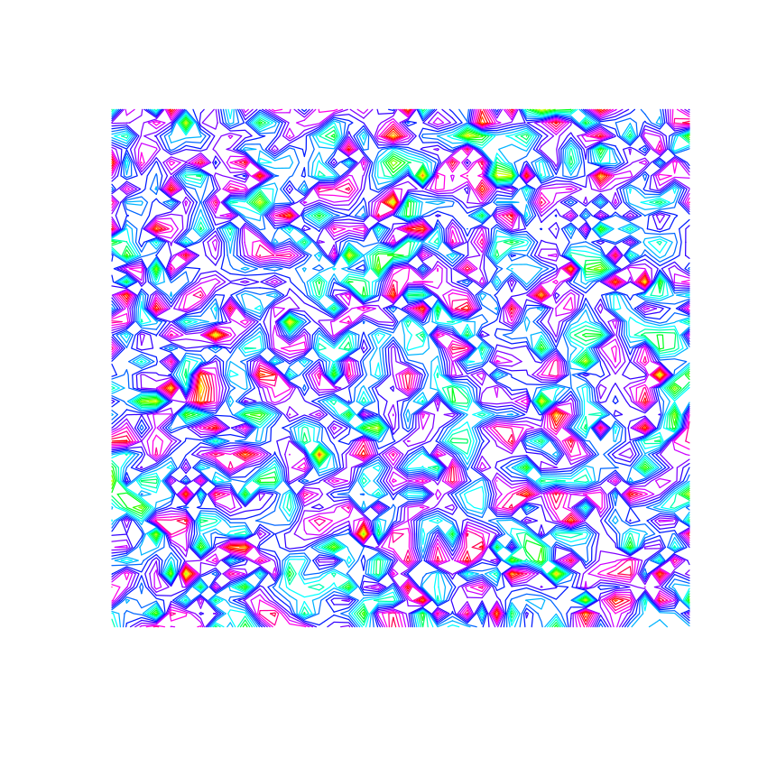

```r
tcol <-  rainbow(20)
contour(z = data, nlevel=40, col =tcol,labcex = 0.001, axes = FALSE )
```

«